# Zotero group NFF

Published

16 October 2026

Zotero data of 16 October 2026 · IPBES Literature Report 0.4.0 · [source code on GitHub](https://github.com/IPBES-Data/IPBES.LiteratureReport)

This report shows the state of the Zotero group **NFF** ([open the group in Zotero](https://www.zotero.org/groups/4937409)). It gives an overview of the literature in the group, and lists the items which should be corrected.

Each item in the lists can be opened in the Zotero **web** library or in the Zotero **app** on your computer, so that it can be corrected directly. Corrected items disappear from the lists the next time the report is updated. Some checks compare the items with [OpenAlex](https://openalex.org), an open catalogue of scholarly publications.

## Summary

| Status | Check | Items |
| --- | --- | --- |
| ● OK | Retracted publications | 0 |
| ● Please fix | DOI points to a different publication | 4 |
| ● Please fix | Items which are in the group more than once | 66 |
| ● OK | DOI field with an invalid DOI | 0 |
| ● Please fix | DOI field with a link or prefix instead of the DOI | 8 |
| ● Please check | ISSN not in the standard form | 43 |
| ● Please check | DOI in the wrong field | 6 |
| ● Please check | DOI not found in OpenAlex | 18 |
| ● Please check | Missing or unusual publication year | 3 |
| ● Please check | Empty journal, volume, issue or pages, found in OpenAlex | 23 |
| ● Please check | Language not given as a language code | 8 |
| ● Please check | Items without DOI, ISBN, ISSN or URL | 45 |
| ● Please check | Items without DOI, for which OpenAlex has one | 9 |
| ● OK | OpenAlex ID in Extra not valid | 0 |
| ● For information | Items without their OpenAlex ID in Extra | 192 |
| ● For information | Items without tags | 236 |

**Please fix**: these items contain errors. **Please check**: these items may need a correction. **For information**: no action needed unless the group uses this, e.g. tags.

## Items to fix

The lists are sorted by importance. Use the search field above a list to find an item. **web** opens the item in the Zotero web library, **app** in the Zotero app.

### Retracted publications

These publications have been retracted. Check whether they should still be cited, and mark or remove them in Zotero.

**✔ Nothing to fix.**

### DOI points to a different publication

The DOI of these items leads to a publication with a different title or year. Usually the DOI is wrong: open the DOI to see where it leads, and correct it in Zotero. Differences of one year (e.g. published online before print) are not listed.

| Open in Zotero | Title in Zotero | Year in Zotero | The DOI leads to | Its year | DOI |
| --- | --- | --- | --- | --- | --- |
| <a href="https://www.zotero.org/groups/4937409/items/R7PAAP56" target="_blank">web</a> &middot; <a href="zotero://select/groups/4937409/items/R7PAAP56">app</a> | Potential approaches to establishing harmonious river‐human relationships | 2024 | Potential approaches to establishing harmonious river‐human relationships | 2022 | <a href="https://doi.org/10.1002/rra.4097" target="_blank">10.1002/rra.4097</a> |
| <a href="https://www.zotero.org/groups/4937409/items/PLZP8DGG" target="_blank">web</a> &middot; <a href="zotero://select/groups/4937409/items/PLZP8DGG">app</a> | The “value perspectives of nature” scale: A validated scale to measure plural value perspectives of future nature from a transformative angle | 2025 | The Plural Values of Nature scale: An integrated psychometric scale to measure instrumental, intrinsic and relational values. | 2025 | <a href="https://doi.org/10.1101/2025.01.10.632251" target="_blank">10.1101/2025.01.10.632251</a> |
| <a href="https://www.zotero.org/groups/4937409/items/D7HNY7FE" target="_blank">web</a> &middot; <a href="zotero://select/groups/4937409/items/D7HNY7FE">app</a> | Technology Assessment in a Globalized World: Facing the Challenges of Transnational Technology Governance | 2023 | Technology Assessment in a Globalized World | 2023 | <a href="https://doi.org/10.1007/978-3-031-10617-0" target="_blank">10.1007/978-3-031-10617-0</a> |
| <a href="https://www.zotero.org/groups/4937409/items/ZBRSRN62" target="_blank">web</a> &middot; <a href="zotero://select/groups/4937409/items/ZBRSRN62">app</a> | Reimagining futures: Collaborations between artists, designers, and scientists as a roadmap to help solve the climate crisis. | 2021 | Reimagining futures | 2021 | <a href="https://doi.org/10.1525/elementa.2021.00016" target="_blank">10.1525/elementa.2021.00016</a> |

### Items which are in the group more than once

These items are in the group more than once, with the same DOI, or with the same title, year and first author. Keep one copy and merge or delete the others, e.g. with *Duplicate Items* in the Zotero app.

| Open in Zotero | Title | Copies |
| --- | --- | --- |
| <a href="https://www.zotero.org/groups/4937409/items/UQE2HG8F" target="_blank">web</a> &middot; <a href="zotero://select/groups/4937409/items/UQE2HG8F">app</a><br><a href="https://www.zotero.org/group… | What about the negatives? An integrated framework for revealing diverse values of nature and its conservation | 2 |
| <a href="https://www.zotero.org/groups/4937409/items/H74GH7S9" target="_blank">web</a> &middot; <a href="zotero://select/groups/4937409/items/H74GH7S9">app</a><br><a href="https://www.zotero.org/group… | Visioning ecologically diverse and harmonious futures of Korea in Good Anthropocene | 2 |
| <a href="https://www.zotero.org/groups/4937409/items/DVJA72AG" target="_blank">web</a> &middot; <a href="zotero://select/groups/4937409/items/DVJA72AG">app</a><br><a href="https://www.zotero.org/group… | Using the Nature Futures Framework as a lens for developing plural land use scenarios for Europe for 2050 | 2 |
| <a href="https://www.zotero.org/groups/4937409/items/W9E648K9" target="_blank">web</a> &middot; <a href="zotero://select/groups/4937409/items/W9E648K9">app</a><br><a href="https://www.zotero.org/group… | Urban Nature Games for integrating nature-based solutions in urban planning: A review | 2 |
| <a href="https://www.zotero.org/groups/4937409/items/B6AEC8FX" target="_blank">web</a> &middot; <a href="zotero://select/groups/4937409/items/B6AEC8FX">app</a><br><a href="https://www.zotero.org/group… | Urban expansion in the Atlantic Forest: applying the Nature Futures Framework to develop a conceptual model and future scenarios | 2 |
| <a href="https://www.zotero.org/groups/4937409/items/V679UQZQ" target="_blank">web</a> &middot; <a href="zotero://select/groups/4937409/items/V679UQZQ">app</a><br><a href="https://www.zotero.org/group… | Towards a better future for biodiversity and people: Modelling Nature Futures | 2 |
| <a href="https://www.zotero.org/groups/4937409/items/G74S25WM" target="_blank">web</a> &middot; <a href="zotero://select/groups/4937409/items/G74S25WM">app</a><br><a href="https://www.zotero.org/group… | The voices of youth in envisioning positive futures for nature and people | 2 |
| <a href="https://www.zotero.org/groups/4937409/items/CAPM593C" target="_blank">web</a> &middot; <a href="zotero://select/groups/4937409/items/CAPM593C">app</a><br><a href="https://www.zotero.org/group… | The Plural Values of Nature scale: An integrated psychometric scale to measure instrumental, intrinsic and relational values. | 2 |
| <a href="https://www.zotero.org/groups/4937409/items/T9NIR64D" target="_blank">web</a> &middot; <a href="zotero://select/groups/4937409/items/T9NIR64D">app</a><br><a href="https://www.zotero.org/group… | The perspective of youth: envisioning transformative pathways and desirable futures for people and nature | 2 |
| <a href="https://www.zotero.org/groups/4937409/items/39QDDANA" target="_blank">web</a> &middot; <a href="zotero://select/groups/4937409/items/39QDDANA">app</a><br><a href="https://www.zotero.org/group… | The living infinite: Envisioning futures for transformed human-nature relationships on the high seas | 2 |

[output cut: 52 more lines]

### DOI field with an invalid DOI

The DOI field of these items contains something which is not a valid DOI. Correct or remove it.

**✔ Nothing to fix.**

### DOI field with a link or prefix instead of the DOI

The DOI field of these items contains the DOI as a link (`https://doi.org/…`) or with a prefix (`DOI …`). Citation styles add the link themselves, so it would appear twice. Replace it with the DOI only.

| Open in Zotero | Title | Content of the DOI field | DOI |
| --- | --- | --- | --- |
| <a href="https://www.zotero.org/groups/4937409/items/7AIJ6EKB" target="_blank">web</a> &middot; <a href="zotero://select/groups/4937409/items/7AIJ6EKB">app</a> | Climate response to Nature Future scenarios in a regional Earth System Model | https://doi.org/10.1038/s41467-026-70284-8 | <a href="https://doi.org/10.1038/s41467-026-70284-8" target="_blank">10.1038/s41467-026-70284-8</a> |
| <a href="https://www.zotero.org/groups/4937409/items/DAKTV4QK" target="_blank">web</a> &middot; <a href="zotero://select/groups/4937409/items/DAKTV4QK">app</a> | Investigating values of forests in Australia through the Nature Futures Framework | https://doi.org/10.1007/s11625-026-01881-1 | <a href="https://doi.org/10.1007/s11625-026-01881-1" target="_blank">10.1007/s11625-026-01881-1</a> |
| <a href="https://www.zotero.org/groups/4937409/items/GI8C2ZDE" target="_blank">web</a> &middot; <a href="zotero://select/groups/4937409/items/GI8C2ZDE">app</a> | Exploring desirable urban nature futures: a Q study on local planners’ perspectives in Germany | https://doi.org/10.1007/s11625-026-01876-y | <a href="https://doi.org/10.1007/s11625-026-01876-y" target="_blank">10.1007/s11625-026-01876-y</a> |
| <a href="https://www.zotero.org/groups/4937409/items/ADN7Z9EH" target="_blank">web</a> &middot; <a href="zotero://select/groups/4937409/items/ADN7Z9EH">app</a> | Conceptualizing irreconcilable disagreements in the nature futures framework over intrinsic and instrumental values | https://doi.org/10.1177/09632719261437695 | <a href="https://doi.org/10.1177/09632719261437695" target="_blank">10.1177/09632719261437695</a> |
| <a href="https://www.zotero.org/groups/4937409/items/UABT3R6C" target="_blank">web</a> &middot; <a href="zotero://select/groups/4937409/items/UABT3R6C">app</a> | Combining the Viable System Model and Nature Futures Framework. | https://doi.org/10.1007/s11213-025-09718-1 | <a href="https://doi.org/10.1007/s11213-025-09718-1" target="_blank">10.1007/s11213-025-09718-1</a> |
| <a href="https://www.zotero.org/groups/4937409/items/9P8ILX2I" target="_blank">web</a> &middot; <a href="zotero://select/groups/4937409/items/9P8ILX2I">app</a> | Capturing Elements of the Nature Futures Framework Through In Situ Place Descriptions: An Empirical Study in Urban Blue Locations | https://doi.org/10.5281/zenodo.8286255 | <a href="https://doi.org/10.5281/zenodo.8286255" target="_blank">10.5281/zenodo.8286255</a> |
| <a href="https://www.zotero.org/groups/4937409/items/T2X7FRRX" target="_blank">web</a> &middot; <a href="zotero://select/groups/4937409/items/T2X7FRRX">app</a> | The Living Infinite: Envisioning futures for transformed human-nature relationships on the high seas | https://doi.org/10.1016/j.marpol.2023.105644 | <a href="https://doi.org/10.1016/j.marpol.2023.105644" target="_blank">10.1016/j.marpol.2023.105644</a> |
| <a href="https://www.zotero.org/groups/4937409/items/LPTVHBNM" target="_blank">web</a> &middot; <a href="zotero://select/groups/4937409/items/LPTVHBNM">app</a> | Perceptions of Equity in Conservation Scenarios: Half Earth and Sharing the Planet | https://doi.org/10.1016/j.envsci.2023.03.015 | <a href="https://doi.org/10.1016/j.envsci.2023.03.015" target="_blank">10.1016/j.envsci.2023.03.015</a> |

### ISSN not in the standard form

The ISSN field of these items is not in the standard form `1234-567X` (several separated by “,”), or contains something which is not a valid ISSN, e.g. an ISBN.

| Open in Zotero | Title | Content of the ISSN field | Standard form | Not a valid ISSN |
| --- | --- | --- | --- | --- |
| <a href="https://www.zotero.org/groups/4937409/items/UQE2HG8F" target="_blank">web</a> &middot; <a href="zotero://select/groups/4937409/items/UQE2HG8F">app</a> | What about the negatives? An integrated framework for revealing diverse values of nature and its conservation | 2575-8314, 2575-8314 | 2575-8314 | NA |
| <a href="https://www.zotero.org/groups/4937409/items/DVJA72AG" target="_blank">web</a> &middot; <a href="zotero://select/groups/4937409/items/DVJA72AG">app</a> | Using the Nature Futures Framework as a lens for developing plural land use scenarios for Europe for 2050 | 09593780 | 0959-3780 | NA |
| <a href="https://www.zotero.org/groups/4937409/items/W9E648K9" target="_blank">web</a> &middot; <a href="zotero://select/groups/4937409/items/W9E648K9">app</a> | Urban Nature Games for integrating nature-based solutions in urban planning: A review | 01692046 | 0169-2046 | NA |
| <a href="https://www.zotero.org/groups/4937409/items/V679UQZQ" target="_blank">web</a> &middot; <a href="zotero://select/groups/4937409/items/V679UQZQ">app</a> | Towards a better future for biodiversity and people: Modelling Nature Futures | 09593780 | 0959-3780 | NA |
| <a href="https://www.zotero.org/groups/4937409/items/39QDDANA" target="_blank">web</a> &middot; <a href="zotero://select/groups/4937409/items/39QDDANA">app</a> | The living infinite: Envisioning futures for transformed human-nature relationships on the high seas | 0308597X | 0308-597X | NA |
| <a href="https://www.zotero.org/groups/4937409/items/W7MTRV4G" target="_blank">web</a> &middot; <a href="zotero://select/groups/4937409/items/W7MTRV4G">app</a> | Stakeholder Consensus on Conservation Priorities Across Scientific, NGO, and Governmental Sectors | 1755-263X, 1755-263X | 1755-263X | NA |
| <a href="https://www.zotero.org/groups/4937409/items/FD624EE7" target="_blank">web</a> &middot; <a href="zotero://select/groups/4937409/items/FD624EE7">app</a> | Recipe for a scenario: Moving from vision to actionable pathways towards sustainable futures | 27539687, 27539687 | 2753-9687 | NA |
| <a href="https://www.zotero.org/groups/4937409/items/3CR86RH9" target="_blank">web</a> &middot; <a href="zotero://select/groups/4937409/items/3CR86RH9">app</a> | Perceptions of equity in conservation scenarios: Half Earth and Sharing the Planet | 14629011 | 1462-9011 | NA |
| <a href="https://www.zotero.org/groups/4937409/items/MR62DSRC" target="_blank">web</a> &middot; <a href="zotero://select/groups/4937409/items/MR62DSRC">app</a> | Nature Futures Framework scenarios reveal contrasting landscape connectivity for European mammal translocations | 00063207 | 0006-3207 | NA |
| <a href="https://www.zotero.org/groups/4937409/items/UIXAUU4D" target="_blank">web</a> &middot; <a href="zotero://select/groups/4937409/items/UIXAUU4D">app</a> | Nature futures for the urban century: Integrating multiple values into urban management | 14629011 | 1462-9011 | NA |

[output cut: 33 more lines]

### DOI in the wrong field

These items have no DOI in the DOI field, but a DOI in the URL or Extra field. Copy the DOI into the DOI field.

| Open in Zotero | Title | DOI in URL | DOI in Extra |
| --- | --- | --- | --- |
| <a href="https://www.zotero.org/groups/4937409/items/SZQ8KIFW" target="_blank">web</a> &middot; <a href="zotero://select/groups/4937409/items/SZQ8KIFW">app</a> | ネイチャー・フューチャー枠組：人々、自然、母なる地球 , にとって望ましい将来のシナリオとモデルの開発を支援する柔軟なツール、およびその方法論に関するガイダンス | <a href="https://doi.org/10.5281/zenodo.16416226" target="_blank">10.5281/zenodo.16416226</a> |  |
| <a href="https://www.zotero.org/groups/4937409/items/DA77Y9IB" target="_blank">web</a> &middot; <a href="zotero://select/groups/4937409/items/DA77Y9IB">app</a> | Regional Youth Workshop on IPBES for Europe and Central Asia | <a href="https://doi.org/10.19217/skr730" target="_blank">10.19217/skr730</a> |  |
| <a href="https://www.zotero.org/groups/4937409/items/NUZKZ3FC" target="_blank">web</a> &middot; <a href="zotero://select/groups/4937409/items/NUZKZ3FC">app</a> | The library includes only publications which explicitly mention the Nature Futures Framework, found through a systematic literature search (https://doi.org/10.5281/zenodo.7885022). If you would like t… | <a href="https://doi.org/10.5281/zenodo.6396542" target="_blank">10.5281/zenodo.6396542</a> |  |
| <a href="https://www.zotero.org/groups/4937409/items/B48QGH46" target="_blank">web</a> &middot; <a href="zotero://select/groups/4937409/items/B48QGH46">app</a> | New Narratives for Nature: operationalizing the IPBES Nature Futures Scenarios | <a href="https://doi.org/10.5281/zenodo.7727013" target="_blank">10.5281/zenodo.7727013</a> |  |
| <a href="https://www.zotero.org/groups/4937409/items/3HMAHPSF" target="_blank">web</a> &middot; <a href="zotero://select/groups/4937409/items/3HMAHPSF">app</a> | Global Modelling of Biodiversity and Ecosystem Services | <a href="https://doi.org/10.5281/zenodo.7726976" target="_blank">10.5281/zenodo.7726976</a> |  |
| <a href="https://www.zotero.org/groups/4937409/items/359SIE54" target="_blank">web</a> &middot; <a href="zotero://select/groups/4937409/items/359SIE54">app</a> | From visions to scenarios for nature and nature’s contributions to people for the 21st century | <a href="https://doi.org/10.5281/zenodo.7726944" target="_blank">10.5281/zenodo.7726944</a> |  |

### DOI not found in OpenAlex

These DOIs were not found in OpenAlex. The DOI may be wrong: open it to check. If it leads to the right publication, the publication is simply not (yet) in OpenAlex and nothing needs to be done.

| Open in Zotero | Title | DOI |
| --- | --- | --- |
| <a href="https://www.zotero.org/groups/4937409/items/H74GH7S9" target="_blank">web</a> &middot; <a href="zotero://select/groups/4937409/items/H74GH7S9">app</a> | Visioning ecologically diverse and harmonious futures of Korea in Good Anthropocene | <a href="https://doi.org/10.31235/osf.io/g3zb4" target="_blank">10.31235/osf.io/g3zb4</a> |
| <a href="https://www.zotero.org/groups/4937409/items/5EJHSJR8" target="_blank">web</a> &middot; <a href="zotero://select/groups/4937409/items/5EJHSJR8">app</a> | Regional Youth Workshop on IPBES for Europe and Central Asia: Report on the workshop held 6-10 November 2023 at the International Academy for Nature Conservation, Isle of Vilm, Germany | <a href="https://doi.org/10.19217/skr730" target="_blank">10.19217/skr730</a> |
| <a href="https://www.zotero.org/groups/4937409/items/7Q8AC8I4" target="_blank">web</a> &middot; <a href="zotero://select/groups/4937409/items/7Q8AC8I4">app</a> | Predicted decline in common bird and butterfly species despite conservation policy scenarios in Europe | <a href="https://doi.org/10.48550/arxiv.2509.18227" target="_blank">10.48550/arxiv.2509.18227</a> |
| <a href="https://www.zotero.org/groups/4937409/items/QN7DPRXF" target="_blank">web</a> &middot; <a href="zotero://select/groups/4937409/items/QN7DPRXF">app</a> | Mosquitoes, mushrooms, magic: Africanfuturist SF for nature's futures | <a href="https://doi.org/10.5281/zenodo.7625005" target="_blank">10.5281/zenodo.7625005</a> |
| <a href="https://www.zotero.org/groups/4937409/items/EQWJI58N" target="_blank">web</a> &middot; <a href="zotero://select/groups/4937409/items/EQWJI58N">app</a> | Capturing Elements of the Nature Futures Framework Through In Situ Place Descriptions: An Empirical Study in Urban Blue Locations | <a href="https://doi.org/10.5281/zenodo.8286255" target="_blank">10.5281/zenodo.8286255</a> |
| <a href="https://www.zotero.org/groups/4937409/items/29RIPENP" target="_blank">web</a> &middot; <a href="zotero://select/groups/4937409/items/29RIPENP">app</a> | Anticipating the impacts of environmental change on plant species of conservation concern in the Iberian Peninsula | <a href="https://doi.org/10.34626/7aqp-wf46" target="_blank">10.34626/7aqp-wf46</a> |
| <a href="https://www.zotero.org/groups/4937409/items/DM3MWDFE" target="_blank">web</a> &middot; <a href="zotero://select/groups/4937409/items/DM3MWDFE">app</a> | Envisioning nature positive futures for Europe: Inspiring transformative change at the biodiversity nexus | <a href="https://doi.org/10.31223/x57q5q" target="_blank">10.31223/x57q5q</a> |
| <a href="https://www.zotero.org/groups/4937409/items/ZG35EJR2" target="_blank">web</a> &middot; <a href="zotero://select/groups/4937409/items/ZG35EJR2">app</a> | Visioning ecologically diverse and harmonious futures of Korea in Good Anthropocene | <a href="https://doi.org/10.31235/osf.io/g3zb4" target="_blank">10.31235/osf.io/g3zb4</a> |
| <a href="https://www.zotero.org/groups/4937409/items/E2FPGN6J" target="_blank">web</a> &middot; <a href="zotero://select/groups/4937409/items/E2FPGN6J">app</a> | Narratives for positive nature futures in Europe | <a href="https://doi.org/10.1101/2024.10.04.616255" target="_blank">10.1101/2024.10.04.616255</a> |
| <a href="https://www.zotero.org/groups/4937409/items/DNXGA5FJ" target="_blank">web</a> &middot; <a href="zotero://select/groups/4937409/items/DNXGA5FJ">app</a> | The Past and Future of the Fisheries and Marine Ecosystem Model Intercomparison Project | <a href="https://doi.org/10.22541/essoar.170542252.20348236/v1" target="_blank">10.22541/essoar.170542252.20348236/v1</a> |

[output cut: 8 more lines]

### Missing or unusual publication year

These items have no date, a date from which no year could be read, or a year in the future. Correct the date in Zotero.

| Open in Zotero | Title | Date | Problem | Date in OpenAlex |
| --- | --- | --- | --- | --- |
| <a href="https://www.zotero.org/groups/4937409/items/A6YE4M8M" target="_blank">web</a> &middot; <a href="zotero://select/groups/4937409/items/A6YE4M8M">app</a> |  |  | No date | NA |
| <a href="https://www.zotero.org/groups/4937409/items/9P8ILX2I" target="_blank">web</a> &middot; <a href="zotero://select/groups/4937409/items/9P8ILX2I">app</a> | Capturing Elements of the Nature Futures Framework Through In Situ Place Descriptions: An Empirical Study in Urban Blue Locations |  | No date | NA |
| <a href="https://www.zotero.org/groups/4937409/items/NUZKZ3FC" target="_blank">web</a> &middot; <a href="zotero://select/groups/4937409/items/NUZKZ3FC">app</a> | The library includes only publications which explicitly mention the Nature Futures Framework, found through a systematic literature search (https://doi.org/10.5281/zenodo.7885022). If you would like t… |  | No date | NA |

### Empty journal, volume, issue or pages, found in OpenAlex

These journal articles have an empty journal, volume, issue or pages field, and OpenAlex has the value for their DOI. Check it with the DOI and fill in the field.

| Open in Zotero | Title | Field | Value in OpenAlex | DOI |
| --- | --- | --- | --- | --- |
| <a href="https://www.zotero.org/groups/4937409/items/E9B7EJNX" target="_blank">web</a> &middot; <a href="zotero://select/groups/4937409/items/E9B7EJNX">app</a> | A plea for more freshwater experts in IPBES | Volume | 33 | <a href="https://doi.org/10.1002/aqc.3956" target="_blank">10.1002/aqc.3956</a> |
| <a href="https://www.zotero.org/groups/4937409/items/E9B7EJNX" target="_blank">web</a> &middot; <a href="zotero://select/groups/4937409/items/E9B7EJNX">app</a> | A plea for more freshwater experts in IPBES | Issue | 6 | <a href="https://doi.org/10.1002/aqc.3956" target="_blank">10.1002/aqc.3956</a> |
| <a href="https://www.zotero.org/groups/4937409/items/796G8DXN" target="_blank">web</a> &middot; <a href="zotero://select/groups/4937409/items/796G8DXN">app</a> | Bringing the Nature Futures Framework to life: creating a set of illustrative narratives of nature futures | Pages | 1-20 | <a href="https://doi.org/10.1007/s11625-023-01316-1" target="_blank">10.1007/s11625-023-01316-1</a> |
| <a href="https://www.zotero.org/groups/4937409/items/MCKBG9CB" target="_blank">web</a> &middot; <a href="zotero://select/groups/4937409/items/MCKBG9CB">app</a> | Bringing the Nature Futures Framework to life: creating a set of illustrative narratives of nature futures | Pages | 1-20 | <a href="https://doi.org/10.1007/s11625-023-01316-1" target="_blank">10.1007/s11625-023-01316-1</a> |
| <a href="https://www.zotero.org/groups/4937409/items/7AIJ6EKB" target="_blank">web</a> &middot; <a href="zotero://select/groups/4937409/items/7AIJ6EKB">app</a> | Climate response to Nature Future scenarios in a regional Earth System Model | Journal | Nature Communications | <a href="https://doi.org/10.1038/s41467-026-70284-8" target="_blank">10.1038/s41467-026-70284-8</a> |
| <a href="https://www.zotero.org/groups/4937409/items/UABT3R6C" target="_blank">web</a> &middot; <a href="zotero://select/groups/4937409/items/UABT3R6C">app</a> | Combining the Viable System Model and Nature Futures Framework. | Journal | Systemic Practice and Action Research | <a href="https://doi.org/10.1007/s11213-025-09718-1" target="_blank">10.1007/s11213-025-09718-1</a> |
| <a href="https://www.zotero.org/groups/4937409/items/UABT3R6C" target="_blank">web</a> &middot; <a href="zotero://select/groups/4937409/items/UABT3R6C">app</a> | Combining the Viable System Model and Nature Futures Framework. | Volume | 38 | <a href="https://doi.org/10.1007/s11213-025-09718-1" target="_blank">10.1007/s11213-025-09718-1</a> |
| <a href="https://www.zotero.org/groups/4937409/items/UABT3R6C" target="_blank">web</a> &middot; <a href="zotero://select/groups/4937409/items/UABT3R6C">app</a> | Combining the Viable System Model and Nature Futures Framework. | Issue | 2 | <a href="https://doi.org/10.1007/s11213-025-09718-1" target="_blank">10.1007/s11213-025-09718-1</a> |
| <a href="https://www.zotero.org/groups/4937409/items/GLMB5ETH" target="_blank">web</a> &middot; <a href="zotero://select/groups/4937409/items/GLMB5ETH">app</a> | Contribution of freshwater metazooplankton to aquatic ecosystem services: an overview | Volume | 850 | <a href="https://doi.org/10.1007/s10750-022-05001-9" target="_blank">10.1007/s10750-022-05001-9</a> |
| <a href="https://www.zotero.org/groups/4937409/items/GLMB5ETH" target="_blank">web</a> &middot; <a href="zotero://select/groups/4937409/items/GLMB5ETH">app</a> | Contribution of freshwater metazooplankton to aquatic ecosystem services: an overview | Issue | 12-13 | <a href="https://doi.org/10.1007/s10750-022-05001-9" target="_blank">10.1007/s10750-022-05001-9</a> |

[output cut: 31 more lines]

### Language not given as a language code

The language of these items is not given as a language code (`en`, `fr`, `en-US`), e.g. as `English` or `eng`. Citation styles only recognise the codes. Where the language was recognised, the code is shown; otherwise look up the code in the [ISO 639-1 list](https://en.wikipedia.org/wiki/List_of_ISO_639_language_codes).

| Open in Zotero | Title | Language | Language code |
| --- | --- | --- | --- |
| <a href="https://www.zotero.org/groups/4937409/items/N6JK836A" target="_blank">web</a> &middot; <a href="zotero://select/groups/4937409/items/N6JK836A">app</a> | Envisioning the Futures of Mother Earth from a Cosmobiocentric Approach | English | en |
| <a href="https://www.zotero.org/groups/4937409/items/PS5TXKCD" target="_blank">web</a> &middot; <a href="zotero://select/groups/4937409/items/PS5TXKCD">app</a> | Anticipating the impacts of environmental change on plant species of conservation concern in the Iberian Peninsula | eng | en |
| <a href="https://www.zotero.org/groups/4937409/items/JDUH6YC4" target="_blank">web</a> &middot; <a href="zotero://select/groups/4937409/items/JDUH6YC4">app</a> | Plurality in transformative change: three pathways toward nature-positive Europe(s) | en-us | en-US |
| <a href="https://www.zotero.org/groups/4937409/items/EB59SWS3" target="_blank">web</a> &middot; <a href="zotero://select/groups/4937409/items/EB59SWS3">app</a> | Fish communities can simultaneously contribute to nature and people across the world’s tropical reefs | English | en |
| <a href="https://www.zotero.org/groups/4937409/items/SZQ8KIFW" target="_blank">web</a> &middot; <a href="zotero://select/groups/4937409/items/SZQ8KIFW">app</a> | ネイチャー・フューチャー枠組：人々、自然、母なる地球 , にとって望ましい将来のシナリオとモデルの開発を支援する柔軟なツール、およびその方法論に関するガイダンス | Japanese | ja |
| <a href="https://www.zotero.org/groups/4937409/items/DA77Y9IB" target="_blank">web</a> &middot; <a href="zotero://select/groups/4937409/items/DA77Y9IB">app</a> | Regional Youth Workshop on IPBES for Europe and Central Asia | eng | en |
| <a href="https://www.zotero.org/groups/4937409/items/AU93UQNE" target="_blank">web</a> &middot; <a href="zotero://select/groups/4937409/items/AU93UQNE">app</a> | ENVISIONING THE FUTURE OF MOTHER EARTH FROM A COSMOBIOCENTRICS APPROACH. FUTURE TRAJECTORIES IN HARMONY WITH MOTHER EARTH IN BOLIVIA.: Method of Analysis and Metrics for Living Well | English | en |
| <a href="https://www.zotero.org/groups/4937409/items/USVZ7UFI" target="_blank">web</a> &middot; <a href="zotero://select/groups/4937409/items/USVZ7UFI">app</a> | Enhancing the use of scenario-based biodiversity information in conservation policy and practice | eng | en |

### Items without DOI, ISBN, ISSN or URL

Readers cannot easily find these items. Add a DOI, ISBN, ISSN or URL if one exists. Some items, e.g. personal communications, have none.

| Open in Zotero | Title | Type |
| --- | --- | --- |
| <a href="https://www.zotero.org/groups/4937409/items/F2BZEFCC" target="_blank">web</a> &middot; <a href="zotero://select/groups/4937409/items/F2BZEFCC">app</a> | Visions and plausible pathways for positive lake futures in the English Lake District, UK | report |
| <a href="https://www.zotero.org/groups/4937409/items/TRTBICK2" target="_blank">web</a> &middot; <a href="zotero://select/groups/4937409/items/TRTBICK2">app</a> | Utilising the Nature Futures Framework to identify positive pathways for marine invasive seaweeds | report |
| <a href="https://www.zotero.org/groups/4937409/items/ZG5MHCBJ" target="_blank">web</a> &middot; <a href="zotero://select/groups/4937409/items/ZG5MHCBJ">app</a> | Risk and uncertainty attitude and climate change perception of forestry professionals in Nepal in line with IPBES NFF narratives | report |
| <a href="https://www.zotero.org/groups/4937409/items/TIMTHJPJ" target="_blank">web</a> &middot; <a href="zotero://select/groups/4937409/items/TIMTHJPJ">app</a> | Reimagining human-environment futures: Scenario building using the IPBES Nature Futures Framework | report |
| <a href="https://www.zotero.org/groups/4937409/items/HKM3TZS2" target="_blank">web</a> &middot; <a href="zotero://select/groups/4937409/items/HKM3TZS2">app</a> | Plurality in transformative change: three pathways toward nature-positive Europe(s) | report |
| <a href="https://www.zotero.org/groups/4937409/items/AHWAWF3N" target="_blank">web</a> &middot; <a href="zotero://select/groups/4937409/items/AHWAWF3N">app</a> | Performance of terrestrial protected areas under the Nature Futures prism | report |
| <a href="https://www.zotero.org/groups/4937409/items/6UUPFH2H" target="_blank">web</a> &middot; <a href="zotero://select/groups/4937409/items/6UUPFH2H">app</a> | Navigating different understandings of the Biosphere Reserve concept through future visioning: A case study of the Appennino Tosco-Emiliano in Italy | report |
| <a href="https://www.zotero.org/groups/4937409/items/VW33BHWB" target="_blank">web</a> &middot; <a href="zotero://select/groups/4937409/items/VW33BHWB">app</a> | Moving from nature based solutions scenarios in the Netherlands to international and LMIC contexts : interNationaL2120 | report |
| <a href="https://www.zotero.org/groups/4937409/items/WM6KZZXX" target="_blank">web</a> &middot; <a href="zotero://select/groups/4937409/items/WM6KZZXX">app</a> | Managing biodiversity in the Anthropocene: discussing the Nature Futures Framework as a tool for adaptive decision-making for nature under climate change | journal article |
| <a href="https://www.zotero.org/groups/4937409/items/456UAPH5" target="_blank">web</a> &middot; <a href="zotero://select/groups/4937409/items/456UAPH5">app</a> | Exploring youth’s nature values and desirable future visions of the Royal National City Park in Stockholm | report |

[output cut: 35 more lines]

### Items without DOI, for which OpenAlex has one

OpenAlex was searched by title for items without a DOI (journal articles, books, book sections, reports, conference papers, theses, preprints). The publications found are compared by title, year and first author: a *likely* match agrees in all three, a *possible* match has a similar title, but e.g. a different year or author. Open the DOI to check that it is the same publication, and add the DOI in Zotero.

| Open in Zotero | Title | Year | Author | Found in OpenAlex | Year (OpenAlex) | Author (OpenAlex) | Match | DOI |
| --- | --- | --- | --- | --- | --- | --- | --- | --- |
| <a href="https://www.zotero.org/groups/4937409/items/NX4H36FW" target="_blank">web</a> &middot; <a href="zotero://select/groups/4937409/items/NX4H36FW">app</a> | Higher Education Futures: The Transformative Potential of Using Critical Foresights Practices & Arts Based Research in Our Brittle, Anxious, Non-Linear, and Incomprehensible (BANI) World | 2022 | Mullooly, Sheila Christine | Higher Education Futures: The Transformative Potential of Using Critical Foresights Practices & Arts Based Research in Our Brittle, Anxious, Non-Linear, and Incomprehensible (BANI) World | 2022 | Sheila Mullooly | likely | <a href="https://doi.org/10.15760/etd.7932" target="_blank">10.15760/etd.7932</a> |
| <a href="https://www.zotero.org/groups/4937409/items/WGSU2TT3" target="_blank">web</a> &middot; <a href="zotero://select/groups/4937409/items/WGSU2TT3">app</a> | Living Planet Report 2020 - Bending the curve of biodiversity loss | 2020 | WWF | LIVING PLANET REPORT 2020: BENDING THE CURVE OF BIODIVERSITY LOSS | 2022 | NA | possible | <a href="https://doi.org/10.1163/9789004322714_cclc_2020-0074-0399" target="_blank">10.1163/9789004322714_cclc_2020-0074-0399</a> |
| <a href="https://www.zotero.org/groups/4937409/items/WM6KZZXX" target="_blank">web</a> &middot; <a href="zotero://select/groups/4937409/items/WM6KZZXX">app</a> | Managing biodiversity in the Anthropocene: discussing the Nature Futures Framework as a tool for adaptive decision-making for nature under climate change | 2022 | Palacios‑Abrantes et al. | Managing biodiversity in the Anthropocene: discussing the Nature Futures Framework as a tool for adaptive decision-making for nature under climate change | 2022 | Juliano Palacios‐Abrantes | possible: DOI used by another item in the group (duplicate?) | <a href="https://doi.org/10.1007/s11625-022-01200-4" target="_blank">10.1007/s11625-022-01200-4</a> |
| <a href="https://www.zotero.org/groups/4937409/items/HKM3TZS2" target="_blank">web</a> &middot; <a href="zotero://select/groups/4937409/items/HKM3TZS2">app</a> | Plurality in transformative change: three pathways toward nature-positive Europe(s) | 2025 | de Pater et al. | Plurality in transformative change: three pathways toward nature-positive Europe(s) | 2025 | Mara de Pater | possible | <a href="https://doi.org/10.5445/ir/1000182647" target="_blank">10.5445/ir/1000182647</a> |
| <a href="https://www.zotero.org/groups/4937409/items/HKM3TZS2" target="_blank">web</a> &middot; <a href="zotero://select/groups/4937409/items/HKM3TZS2">app</a> | Plurality in transformative change: three pathways toward nature-positive Europe(s) | 2025 | de Pater et al. | Plurality in transformative change: three pathways toward nature-positive Europe(s) | 2025 | Mara de Pater | possible: DOI used by another item in the group (duplicate?) | <a href="https://doi.org/10.31235/osf.io/v4rfh_v1" target="_blank">10.31235/osf.io/v4rfh_v1</a> |
| <a href="https://www.zotero.org/groups/4937409/items/HKM3TZS2" target="_blank">web</a> &middot; <a href="zotero://select/groups/4937409/items/HKM3TZS2">app</a> | Plurality in transformative change: three pathways toward nature-positive Europe(s) | 2025 | de Pater et al. | Plurality in transformative change: Three co‐created pathways toward nature‐positive Europe(s) | 2026 | Mara de Pater | possible | <a href="https://doi.org/10.1002/pan3.70418" target="_blank">10.1002/pan3.70418</a> |
| <a href="https://www.zotero.org/groups/4937409/items/ZHK75Q8C" target="_blank">web</a> &middot; <a href="zotero://select/groups/4937409/items/ZHK75Q8C">app</a> | Reimagining Coral Reef Futures | 2025 | Ignacio Gianelli et al | Reimagining coral reef futures | 2026 | Ignacio Gianelli | possible: DOI used by another item in the group (duplicate?) | <a href="https://doi.org/10.1038/s44183-025-00179-6" target="_blank">10.1038/s44183-025-00179-6</a> |
| <a href="https://www.zotero.org/groups/4937409/items/TIMTHJPJ" target="_blank">web</a> &middot; <a href="zotero://select/groups/4937409/items/TIMTHJPJ">app</a> | Reimagining human-environment futures: Scenario building using the IPBES Nature Futures Framework | 2025 | Mariano et al. | Reimagining human-environment futures: Scenario building using the IPBES Nature Futures Framework | 2025 | Bryan Joel S. Mariano | possible | <a href="https://doi.org/10.2139/ssrn.5186645" target="_blank">10.2139/ssrn.5186645</a> |
| <a href="https://www.zotero.org/groups/4937409/items/V6U389GV" target="_blank">web</a> &middot; <a href="zotero://select/groups/4937409/items/V6U389GV">app</a> | Reimagining human-environment futures: Scenario building using the IPBES Nature Futures Framework | 2025 | Mariano, Bryan Joel | Reimagining human-environment futures: Scenario building using the IPBES Nature Futures Framework | 2025 | Bryan Joel S. Mariano | likely | <a href="https://doi.org/10.2139/ssrn.5186645" target="_blank">10.2139/ssrn.5186645</a> |
| <a href="https://www.zotero.org/groups/4937409/items/H8G4GKMP" target="_blank">web</a> &middot; <a href="zotero://select/groups/4937409/items/H8G4GKMP">app</a> | Report of the indigenous and local knowledge dialogue workshop on scenarios and the Nature Futures Framework | 2021 | IPBES | Report of the indigenous and local knowledge dialogue workshop on scenarios and the Nature Futures Framework | 2021 | Intergovernmental Science-Policy Platform on Biodiversity and Ecosystem Services | possible | <a href="https://doi.org/10.5281/zenodo.21771324" target="_blank">10.5281/zenodo.21771324</a> |

[output cut: 1 more lines]

### OpenAlex ID in Extra not valid

The line `OpenAlex: …` in the Extra field of these items is not an OpenAlex ID, is not in OpenAlex (wrong, or the record was merged into another one), or leads to a different publication. Open the item and the OpenAlex record to check, and correct or remove the line.

**✔ Nothing to fix.**

### Items without their OpenAlex ID in Extra

These items were found in OpenAlex by their DOI, but their Extra field has no line `OpenAlex: W…` with the ID of the publication in OpenAlex, or a different one. The ID links the item to OpenAlex. A different ID can come from OpenAlex merging records; open both to check.

| Open in Zotero | Title | OpenAlex ID | ID in Extra | DOI |
| --- | --- | --- | --- | --- |
| <a href="https://www.zotero.org/groups/4937409/items/UQE2HG8F" target="_blank">web</a> &middot; <a href="zotero://select/groups/4937409/items/UQE2HG8F">app</a> | What about the negatives? An integrated framework for revealing diverse values of nature and its conservation | W4404051557 | NA | <a href="https://doi.org/10.1002/pan3.10750" target="_blank">10.1002/pan3.10750</a> |
| <a href="https://www.zotero.org/groups/4937409/items/DVJA72AG" target="_blank">web</a> &middot; <a href="zotero://select/groups/4937409/items/DVJA72AG">app</a> | Using the Nature Futures Framework as a lens for developing plural land use scenarios for Europe for 2050 | W4387657521 | NA | <a href="https://doi.org/10.1016/j.gloenvcha.2023.102766" target="_blank">10.1016/j.gloenvcha.2023.102766</a> |
| <a href="https://www.zotero.org/groups/4937409/items/W9E648K9" target="_blank">web</a> &middot; <a href="zotero://select/groups/4937409/items/W9E648K9">app</a> | Urban Nature Games for integrating nature-based solutions in urban planning: A review | W4385604737 | NA | <a href="https://doi.org/10.1016/j.landurbplan.2023.104860" target="_blank">10.1016/j.landurbplan.2023.104860</a> |
| <a href="https://www.zotero.org/groups/4937409/items/B6AEC8FX" target="_blank">web</a> &middot; <a href="zotero://select/groups/4937409/items/B6AEC8FX">app</a> | Urban expansion in the Atlantic Forest: applying the Nature Futures Framework to develop a conceptual model and future scenarios | W3028512803 | NA | <a href="https://doi.org/10.1590/1676-0611-bn-2019-0904" target="_blank">10.1590/1676-0611-bn-2019-0904</a> |
| <a href="https://www.zotero.org/groups/4937409/items/Q9C7BUQP" target="_blank">web</a> &middot; <a href="zotero://select/groups/4937409/items/Q9C7BUQP">app</a> | Tracking the Progress Towards Preferable Biodiversity and Climate Futures in the Barotse Cultural Landscape of Zambia | W4416277779 | NA | <a href="https://doi.org/10.1093/9780198945222.003.0102" target="_blank">10.1093/9780198945222.003.0102</a> |
| <a href="https://www.zotero.org/groups/4937409/items/V679UQZQ" target="_blank">web</a> &middot; <a href="zotero://select/groups/4937409/items/V679UQZQ">app</a> | Towards a better future for biodiversity and people: Modelling Nature Futures | W4380362703 | NA | <a href="https://doi.org/10.1016/j.gloenvcha.2023.102681" target="_blank">10.1016/j.gloenvcha.2023.102681</a> |
| <a href="https://www.zotero.org/groups/4937409/items/G74S25WM" target="_blank">web</a> &middot; <a href="zotero://select/groups/4937409/items/G74S25WM">app</a> | The voices of youth in envisioning positive futures for nature and people | W3088840211 | NA | <a href="https://doi.org/10.1080/26395916.2020.1821095" target="_blank">10.1080/26395916.2020.1821095</a> |
| <a href="https://www.zotero.org/groups/4937409/items/CAPM593C" target="_blank">web</a> &middot; <a href="zotero://select/groups/4937409/items/CAPM593C">app</a> | The Plural Values of Nature scale: An integrated psychometric scale to measure instrumental, intrinsic and relational values. | W4406354140 | NA | <a href="https://doi.org/10.1101/2025.01.10.632251" target="_blank">10.1101/2025.01.10.632251</a> |
| <a href="https://www.zotero.org/groups/4937409/items/T9NIR64D" target="_blank">web</a> &middot; <a href="zotero://select/groups/4937409/items/T9NIR64D">app</a> | The perspective of youth: envisioning transformative pathways and desirable futures for people and nature | W4410729584 | NA | <a href="https://doi.org/10.1007/s11625-025-01693-9" target="_blank">10.1007/s11625-025-01693-9</a> |
| <a href="https://www.zotero.org/groups/4937409/items/39QDDANA" target="_blank">web</a> &middot; <a href="zotero://select/groups/4937409/items/39QDDANA">app</a> | The living infinite: Envisioning futures for transformed human-nature relationships on the high seas | W4382236973 | NA | <a href="https://doi.org/10.1016/j.marpol.2023.105644" target="_blank">10.1016/j.marpol.2023.105644</a> |

[output cut: 182 more lines]

### Items without tags

These items have no tags. This only matters if the group uses tags, e.g. to assign items to chapters.

| Open in Zotero | Title | Type |
| --- | --- | --- |
| <a href="https://www.zotero.org/groups/4937409/items/UQE2HG8F" target="_blank">web</a> &middot; <a href="zotero://select/groups/4937409/items/UQE2HG8F">app</a> | What about the negatives? An integrated framework for revealing diverse values of nature and its conservation | journal article |
| <a href="https://www.zotero.org/groups/4937409/items/F2BZEFCC" target="_blank">web</a> &middot; <a href="zotero://select/groups/4937409/items/F2BZEFCC">app</a> | Visions and plausible pathways for positive lake futures in the English Lake District, UK | report |
| <a href="https://www.zotero.org/groups/4937409/items/H74GH7S9" target="_blank">web</a> &middot; <a href="zotero://select/groups/4937409/items/H74GH7S9">app</a> | Visioning ecologically diverse and harmonious futures of Korea in Good Anthropocene | preprint |
| <a href="https://www.zotero.org/groups/4937409/items/TRTBICK2" target="_blank">web</a> &middot; <a href="zotero://select/groups/4937409/items/TRTBICK2">app</a> | Utilising the Nature Futures Framework to identify positive pathways for marine invasive seaweeds | report |
| <a href="https://www.zotero.org/groups/4937409/items/DVJA72AG" target="_blank">web</a> &middot; <a href="zotero://select/groups/4937409/items/DVJA72AG">app</a> | Using the Nature Futures Framework as a lens for developing plural land use scenarios for Europe for 2050 | journal article |
| <a href="https://www.zotero.org/groups/4937409/items/W9E648K9" target="_blank">web</a> &middot; <a href="zotero://select/groups/4937409/items/W9E648K9">app</a> | Urban Nature Games for integrating nature-based solutions in urban planning: A review | journal article |
| <a href="https://www.zotero.org/groups/4937409/items/B6AEC8FX" target="_blank">web</a> &middot; <a href="zotero://select/groups/4937409/items/B6AEC8FX">app</a> | Urban expansion in the Atlantic Forest: applying the Nature Futures Framework to develop a conceptual model and future scenarios | journal article |
| <a href="https://www.zotero.org/groups/4937409/items/Q9C7BUQP" target="_blank">web</a> &middot; <a href="zotero://select/groups/4937409/items/Q9C7BUQP">app</a> | Tracking the Progress Towards Preferable Biodiversity and Climate Futures in the Barotse Cultural Landscape of Zambia | book section |
| <a href="https://www.zotero.org/groups/4937409/items/MTMFHVUZ" target="_blank">web</a> &middot; <a href="zotero://select/groups/4937409/items/MTMFHVUZ">app</a> | Towards a sustainable Nature Futures Framework: evaluating relational values through stakeholder visions for a desirable future in the Lauwers basin | thesis |
| <a href="https://www.zotero.org/groups/4937409/items/V679UQZQ" target="_blank">web</a> &middot; <a href="zotero://select/groups/4937409/items/V679UQZQ">app</a> | Towards a better future for biodiversity and people: Modelling Nature Futures | journal article |

[output cut: 226 more lines]

## The group at a glance

| Figure | Value |
| --- | --- |
| Items in the group | 309 |
| Items with a valid DOI | 69% |
| DOIs found in OpenAlex | 92% |
| Open access, of the publications found in OpenAlex | 95% |
| Grey literature (reports, theses, web pages, preprints, …) | 35% |
| Items in English | 56% |
| Items without language | 44% |

### Publication years

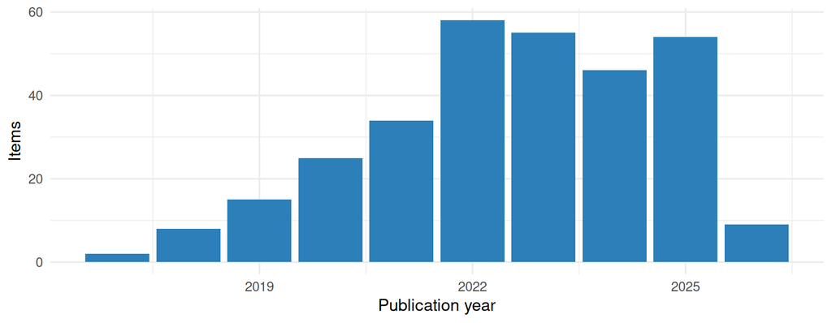

### Types of items

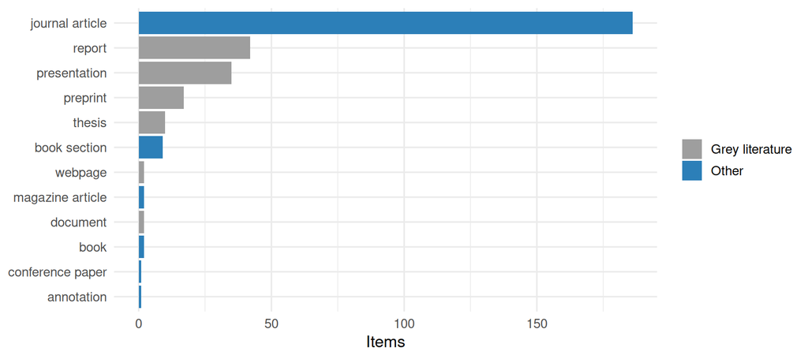

### Open access

Open access status of the publications found in OpenAlex. *Gold* and *diamond*: open in an open access journal; *hybrid*: open in a subscription journal; *green*: an open copy is in a repository; *bronze*: free to read on the publisher’s site; *closed*: not openly available.

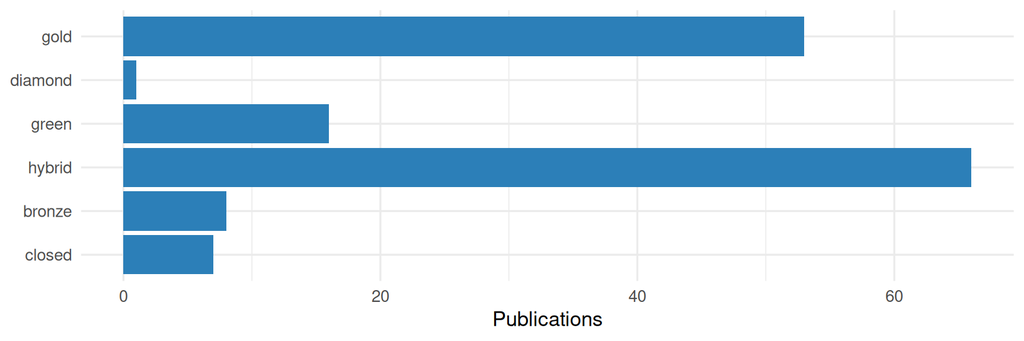

### Most frequent journals

| Journal | Items |
| --- | --- |
| Sustainability Science | 38 |
| Biota Neotropica | 13 |
| Ecosystems and People | 8 |
| Environmental Science & Policy | 7 |
| People and Nature | 7 |
| Global Environmental Change | 5 |
| Biological Conservation | 4 |
| Ecology and Society | 4 |
| Conservation Letters | 3 |
| Ecography | 3 |

### Countries of the authors

Number of publications with at least one author from the country, for the publications found in OpenAlex.

| Country | Publications |
| --- | --- |
| United Kingdom | 51 |
| Netherlands | 48 |
| Sweden | 47 |
| Germany | 44 |
| United States | 40 |
| South Africa | 31 |
| France | 30 |
| Australia | 27 |
| Canada | 26 |
| Japan | 22 |
| Spain | 21 |
| Switzerland | 20 |
| Brazil | 19 |
| Portugal | 17 |
| Austria | 16 |

## How the checks work

**NoteDetails of the checks**

#### identifiers

##### DOI coverage (`met_id_doi`)

Number and share of items with a valid DOI, and items whose DOI field is filled but contains no valid DOI. DOIs are extracted with `openalexPro::extract_doi()` and lower cased.

##### ISBN coverage (`met_id_isbn`)

Number and share of items with an ISBN, overall and for the item types which should have one (`book`, `bookSection`).

##### ISSN coverage (`met_id_issn`)

Number and share of items with an ISSN, overall and for the item types which should have one (`journalArticle`, `magazineArticle`).

##### ISSN not in the standard form (`met_id_issn_form`)

Items whose ISSN field is not in the standard form: each ISSN as `1234-567X` (with hyphen, capital X), several separated by “,”. The ISSNs are checked with their check digit. If all are valid, the standard form is proposed; otherwise the item is listed with the ISSNs which are not valid.

##### DOIs in the wrong field (`met_id_doi_misplaced`)

Items with an empty DOI field but a DOI in the `Url` or `Extra` field. These DOIs are not used for the OpenAlex lookup and should be moved to the DOI field.

##### DOIs in the wrong form (`met_id_doi_form`)

Items whose DOI field contains a valid DOI, but not as a bare DOI: as a link (`https://doi.org/10.…`), with a prefix (`doi:`, `DOI`), URL-encoded (`%5B` for `[`) or with spaces or other characters around it. Citation styles add the link themselves, so a link in the DOI field appears twice in a bibliography. The bare DOI is the one recognised by `openalexPro::extract_doi()`, keeping its upper and lower case.

##### Items without identifier (`met_id_none`)

Items with none of DOI, ISBN, ISSN or Url. These items can neither be checked against OpenAlex nor easily be retrieved by readers.

##### DOIs found in OpenAlex for items without a DOI (`met_id_candidates`)

For items without a DOI, OpenAlex was searched by title (see [get_doi_candidates()]). The works found are compared with the item: title (ignoring case and punctuation), year and the surname of the first author. A work is a *likely* match if the titles are (nearly) the same (similarity at least 0.95), the years differ by at most 1 and the first authors have the same surname (year or author are not compared if the item has none), and the title has at least 4 words (short titles like “Zoonoses” are too general). It is a *possible* match if the titles are similar (at least 0.8). All likely and possible works with a DOI are kept, sorted per item, best first. DOIs used by another item in the group are noted (the item would be a duplicate).

#### metadata

##### Filled fields per item type (`met_meta_fields`)

Percentage of items with a filled field, per item type, for the main fields: Title, Author, Publication Year, Publication Title, Publisher, DOI, ISBN, ISSN, Url, Abstract Note and Language. Not every field is expected for every item type, e.g. reports have no Publication Title.

##### Problematic publication years (`met_meta_year`)

Items whose date is missing (`missing`), from whose date Zotero could not derive a year (`unparseable`), or whose year lies in the future (`future`).

##### Duplicate items (`met_meta_duplicates`)

Items which are in the group more than once, identified by the same DOI, or by the same normalised title (lower case, letters and digits only), publication year and first word of the first author.

##### Language not given as a standard code (`met_meta_language`)

Items whose language is not given as a standard language code, i.e. a two-letter ISO 639-1 code, optionally with a region (`en`, `en-US`), but e.g. as a name (`English`), a three-letter code (`eng`) or in a different spelling (`EN`, `en_us`). Citation styles and other tools only recognise the codes. Where the value is recognised, the standard code is proposed, based on the ISO 639-2 list (R package ISOcodes): codes, three-letter codes and the English names of the languages. Other values, e.g. names in the language itself, several languages or other text, are listed without a proposal.

#### openalex_check

##### Zotero DOIs found in OpenAlex (`met_check_found`)

Valid Zotero DOIs which were / were not found in OpenAlex. A DOI which is not found is either not indexed by OpenAlex or wrong.

##### Retracted works (`met_check_retracted`)

Works flagged as retracted by OpenAlex, with the key of the Zotero item(s) with the same DOI.

##### Wrong DOIs (`met_check_mismatch`)

Items whose DOI points in OpenAlex to a work with a different title or year, which usually means that the wrong DOI is attached to the item. An item is flagged when the title similarity (normalised Levenshtein distance) is below 0.8 or the years differ by more than one.

##### Item type agreement (`met_check_type`)

Zotero item type compared with the OpenAlex work type for items with the same DOI.

##### Missing dates found in OpenAlex (`met_check_date`)

Items without a date whose DOI was found in OpenAlex: the publication date in OpenAlex is proposed. OpenAlex gives 1 January when only the year is known, so such dates are proposed as the year only. Items whose DOI points to a different publication are left out.

##### Empty fields found in OpenAlex (`met_check_fill`)

Journal articles with an empty journal, volume, issue or pages field whose DOI was found in OpenAlex with these details: the values in OpenAlex are proposed. The journal is only taken if the publication is in a journal in OpenAlex (not e.g. a repository). Page ranges which end before they start (e.g. `1260-2`, shortened or wrong) are not proposed. Items whose DOI points to a different publication are left out.

##### OpenAlex ID in the Extra field (`met_check_openalex_id`)

Items whose DOI was found in OpenAlex, compared with the OpenAlex ID noted in their Extra field (a line `OpenAlex: W…`). Items without such a line can get it, which links them to OpenAlex for later checks. Items with a different ID are listed for checking: OpenAlex merges records, and the ID of a merged record redirects to the new one. Items whose DOI points to a different publication are left out.

##### OpenAlex ID in the Extra field not valid (`met_check_extra_id`)

Checks the lines `OpenAlex: …` in the Extra field (looked up by [get_extra_ids()]). A line is not valid if - it is not an OpenAlex work ID (`W` and digits), - the item has several lines with different IDs, - the ID is not in OpenAlex (wrong, or merged into another record), or - the work is a different publication: its DOI is not the DOI of the item, or, for items without DOI, its title is not similar (similarity below 0.8, see [title_similarity()]).

#### profile

##### Publication years (`met_prof_year`)

Number of items per publication year, with cumulative counts. Items without a year are counted as `NA`.

##### Open access status (`met_prof_oa`)

OpenAlex open access status (gold, diamond, green, hybrid, bronze, closed) of the works, overall and per publication year.

##### Top journals (`met_prof_journals`)

The 50 most frequent journals, from the Publication Title in Zotero and the source of the primary location in OpenAlex. Ties at rank 50 are included.

##### Author countries (`met_prof_countries`)

Number of works with at least one author affiliated with an institution in a country, per country (ISO 3166-1 alpha-2 codes from OpenAlex).

##### Item types and grey literature (`met_prof_types`)

Number of items per item type (Zotero) or work type (OpenAlex), and the share of grey literature, i.e. reports, theses, dissertations, web pages, documents, presentations, manuscripts, blog posts and preprints.

##### Languages (`met_prof_language`)

Languages as entered, and normalised to two letter codes (lower case, region removed, English spellings mapped to `en`). Inconsistent codes in the language as entered are a quality issue in themselves.

#### maintenance

##### Group activity (`met_maint_activity`)

Items added per month, and items added / modified in the 30 days before the metrics were calculated.

##### Items without tags (`met_maint_tags`)

Items without manual tags. Automatic tags, e.g. keywords imported from the publisher, are ignored.

IPBES Literature Report 0.4.0 · [source code on GitHub](https://github.com/IPBES-Data/IPBES.LiteratureReport) (© IPBES.LiteratureReport authors, [MIT licence](https://opensource.org/license/mit)) · reports and data on this website: [CC0 1.0](https://creativecommons.org/publicdomain/zero/1.0/) (no rights reserved)